# Module 4: Regularization

## 5. Determine the performance of the fit model against the training set by calculating the root mean square error (RMSE).

```r
# Predict on the training set for different values of lambda

train_y_pred <- predict(ridge_model, s = lambda.min, newx = train_x_scaled)
train_y_pred_1se <- predict(ridge_model_1se, s = lambda.1se, newx = train_x_scaled)

# Calculate RMSE using lambda = lambda.min
rmse_train <- sqrt(mean((train_y - train_y_pred)^2))

# Calculate RMSE using lambda = lambda.1se
rmse_train_1se <- sqrt(mean((train_y - train_y_pred_1se)^2))


rmse_table_train_ridge <- data.frame(
  Lambda = c("Lambda.min", "Lambda.1se"),
  RMSE = c(rmse_train, rmse_train_1se)
)
kable(rmse_table_train_ridge, caption = "Table 1: RMSE Values for Training Sets for Ridge Regression")%>%
  kable_styling(bootstrap_options = c("striped", "hover", "condensed"), full_width = T) %>%
  column_spec(1, bold = TRUE) %>%
  column_spec(1:2, width = "6em")
```

Table 1: RMSE Values for Training Sets for Ridge Regression

| Lambda | RMSE |
| --- | --- |
| Lambda.min | 12.52153 |
| Lambda.1se | 12.92769 |

## 6. Determine the performance of the fit model against the test set by calculating the root mean square error (RMSE). Is your model overfit?

```r
# Predict on the test set using two different lambda's
test_y_pred <- predict(ridge_model, s = lambda.min, newx = test_x_scaled)
test_y_pred_1se <- predict(ridge_model_1se, s = lambda.1se, newx = test_x_scaled)

# Calculate RMSE using lambda.min
rmse_test_ridge <- sqrt(mean((test_y - test_y_pred)^2))


# Calculate RMSE using lambda.1se
rmse_test_1se_ridge <- sqrt(mean((test_y - test_y_pred_1se)^2))

rmse_table_test_ridge <- data.frame(
  Lambda = c("Lambda.min", "Lambda.1se"),
  RMSE = c(rmse_test_ridge, rmse_test_1se_ridge)
)
kable(rmse_table_test_ridge, caption = "Table 2: RMSE Values for Testing Sets for Ridge Regression")%>%
  kable_styling(bootstrap_options = c("striped", "hover", "condensed"), full_width = T) %>%
  column_spec(1, bold = TRUE) %>%
  column_spec(1:2, width = "6em")
```

Table 2: RMSE Values for Testing Sets for Ridge Regression

| Lambda | RMSE |
| --- | --- |
| Lambda.min | 13.06230 |
| Lambda.1se | 12.93791 |

### Q. Is your model overfit?

```r
# Create a data frame to store RMSE values
rmse_table <- data.frame(
  Dataset = c("Training", "Testing", "Difference"),
  RMSE = c(rmse_train, rmse_test_ridge, rmse_test_ridge - rmse_train),
   RMSE_lambda_1se = c(rmse_train_1se, rmse_test_1se_ridge, rmse_test_1se_ridge - rmse_train_1se)
)

kable(rmse_table, caption = "Table 3: RMSE Values for Training and Testing Sets")%>%
  kable_styling(bootstrap_options = c("striped", "hover", "condensed"), full_width = T)%>%
  column_spec(1, bold = TRUE) %>%
  column_spec(1:3, width = "6em")
```

Table 3: RMSE Values for Training and Testing Sets

| Dataset | RMSE | RMSE_lambda_1se |
| --- | --- | --- |
| Training | 12.5215267 | 12.9276906 |
| Testing | 13.0623014 | 12.9379105 |
| Difference | 0.5407747 | 0.0102198 |

**Interpretation:**

A model overfits if there’s a significant difference between the RMSE value of the train and test set (OpenAI,2024). We’ll consider model with `lambda = lambda.1se`, since the difference is lower between train and test RMSE. The model does not appear to be overfitting in our case, since the RMSE for the test set (12.9379) is only slightly higher than the RMSE for the training set (12.9276). This indicates that the model generalizes reasonably well to unseen data.

# **Lasso regression**

## 7. Use the cv.glmnet function to estimate the lambda.min and lambda.1se values. Compare and discuss the values.

- Code has been sourced from 4b_Regularization.Rmd

```r
set.seed(123)

lambda_seq <- 10^seq(2, -2, by = -.1)


train_x     <- model.matrix(Grad.Rate ~. , train)[,-1]
train_y      <- train$Grad.Rate
test_x     <- model.matrix(Grad.Rate ~. , test)[,-1]
test_y      <- test$Grad.Rate

# Standardize features for Lasso regression (OpenAI,2024)
train_x_scaled <- scale(train_x)
test_x_scaled <- scale(test_x, center = attr(train_x_scaled, "scaled:center"), scale = attr(train_x_scaled, "scaled:scale"))

# Finding best value of lambda using cross validation

cv_output  <- cv.glmnet(train_x_scaled, train_y, alpha = 1, lambda = lambda_seq)

lambda.min <- cv_output$lambda.min
lambda.1se <- cv_output$lambda.1se

cat("lambda.min =", lambda.min)
```

```
## lambda.min = 0.1258925
```

```r
cat("\n")
```

```r
cat("lamda.1se =", lambda.1se)
```

```
## lamda.1se = 1
```

**`lambda.min`** (0.1258925) represents the value of the regularization parameter that minimizes cross-validation error, offering the best predictive performance but potentially leading to a more complex model. **`lambda.1se`** (1) is a more conservative choice, within one standard error of the minimum error, leading to a simpler, more interpretable model but possibly at the cost of slightly reduced predictive accuracy.

## 8. Plot the results from the cv.glmnet function and provide an interpretation. What does this plot tell us?

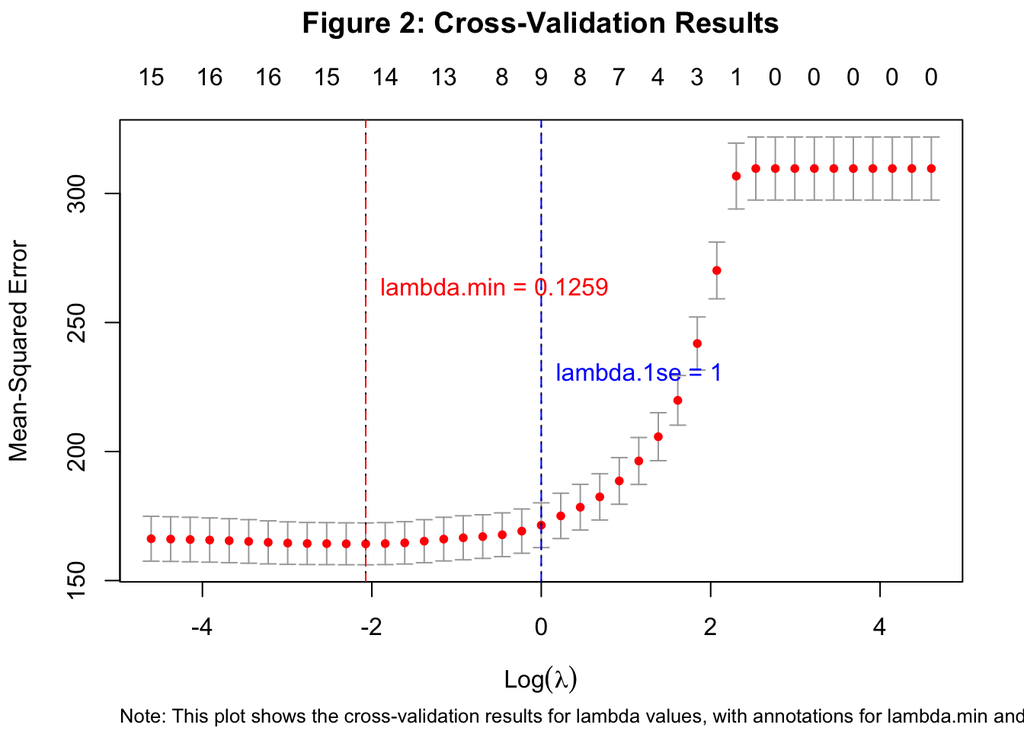

```r
plot(cv_output)

# Add a title
title("Figure 2: Cross-Validation Results", line = 3)

# Add vertical lines for lambda.min and lambda.1se
abline(v = log(cv_output$lambda.min), col = "red", lty = 2)
abline(v = log(cv_output$lambda.1se), col = "blue", lty = 2)

# Annotations with lambda.min and lambda.1se values
text(x = log(cv_output$lambda.min), y = par("usr")[4] * 0.8, labels = paste("lambda.min =", round(cv_output$lambda.min, 4)), pos = 4, col = "red")
text(x = log(cv_output$lambda.1se), y = par("usr")[4] * 0.7, labels = paste("lambda.1se =", round(cv_output$lambda.1se, 4)), pos = 4, col = "blue")

# Add a note at the bottom
mtext("Note: This plot shows the cross-validation results for lambda values, with annotations for lambda.min and lambda.1se.", side = 1, line = 4, adj = 0, cex = 0.8)
```

**Figure 2:** This plot displays the cross-validation curve for different values of the regularization parameter, lambda (λ), plotted on a logarithmic scale (Log(λ)). The y-axis represents the mean squared error (MSE) from cross-validation.

**Interpretation:**

- The model complexity decreases as we move to the right on the x-axis (increasing λ), meaning more regularization and potentially fewer predictors in the model.
- The minimum point of the curve (near the left vertical line) suggests the best-performing model in terms of MSE with the least regularization.
- As we move to larger values of λ, the error increases, which is typical as over-regularization can lead to underfitting.
- The **`lambda.1se (1)`** rule (right vertical line) offers a more regularized model, which may be preferable if we are concerned about overfitting or if we value a simpler model with potentially fewer predictors.

In summary, this plot helps in selecting a value for λ that balances model accuracy and complexity. It provides a visual tool to choose between the most accurate model (**`lambda.min`**) and a more regularized, simpler model (**`lambda.1se`**) that might perform slightly worse but could generalize better to unseen data.